# Intro to spatial data

# [Github repo](https://github.com/nblo/spatial_data/tree/dss-talk)

[figure not shown]

# In 1 hour around the world of spatial data

## Why should I care?

[figure not shown]

### Spatial data is everywhere...

Package tracking

[figure not shown]

Personal fitness tracker

[figure not shown]

Utilities

[figure not shown]

### Spatial data is fun

[figure not shown]

## What are we going to talk about?

- Spatial data 101
- Spatial data wrangling
- Use cases

What are we **not** going to talk about?

- GIS systems
- Spatial data science
- Advanced stuff (network analysis, routing)

# Introduction: What is spatial data?

Data associated with spatial component - objects referencing position on the earth's surface.

Spatial data consists of a spatial information (**where**), attributes (**what**) and sometimes temporal information (**when**).

Examples:

- satellite imagery
- topography
- power lines, cables, substations
- exercise tracking (e.g. running, biking)

# Types of spatial data

## Raster representation (grid)

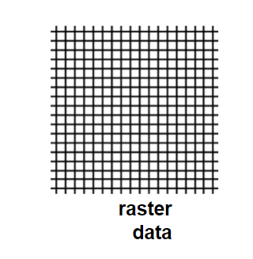

Geographic space is divided into cells.

Each cell is geographically located and receives attributes or properties.

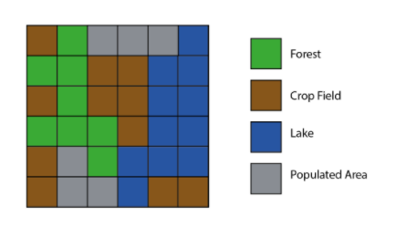

## Vector representation (Points)

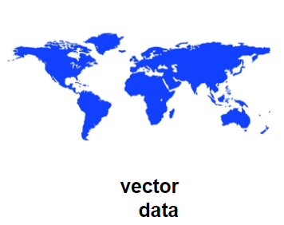

Points with X, Y, (Z) - coordinates which can be connected to more complex geometric types like Polygons or Lines.

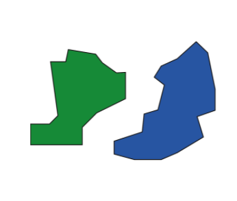

```python
gdf_substations = gpd.read_file("data/substation.geojson")
gdf_substations.sample(5)
```

|  | osm_id | category | longitude | latitude | city | geometry |
| --- | --- | --- | --- | --- | --- | --- |
| 324 | node/4300257335 | substation | 6.951205 | 51.366672 | Essen | POINT (357379.602 5692593.803) |
| 112 | node/1289076460 | substation | 7.015337 | 51.465611 | Essen | POINT (362141.604 5703472.683) |
| 123 | node/1308072560 | substation | 7.038109 | 51.439620 | Essen | POINT (363645.800 5700539.868) |
| 428 | node/7934111915 | substation | 6.986968 | 51.483181 | Essen | POINT (360224.915 5705480.206) |
| 456 | way/55355444 | substation | 7.020660 | 51.448600 | Essen | POLYGON ((362459.526 5701568.026, 362457.071 5... |

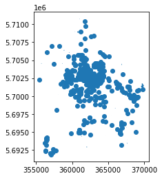

```python
gdf_substations.plot()
```

# Geometric Data Types

## Singular data types

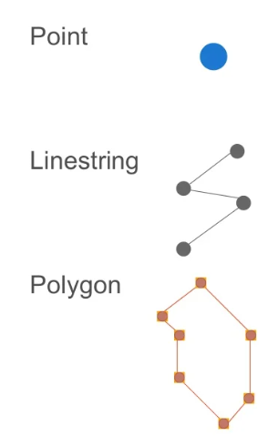

## Combined data types

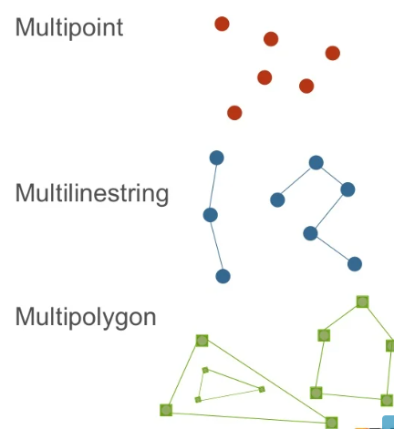

## Examples of data types

[Point](https://www.openstreetmap.org/node/844436661#map=19/51.48840/6.97349)

[Polygons](https://www.openstreetmap.org/way/610528384)

[LineStrings](https://www.openstreetmap.org/relation/1109613#map=15/51.4984/6.9737)

[Multipolygons](https://www.openstreetmap.org/relation/89605) can consist of (combinations of) outer rings and interior rings (holes).

# Projections and coordinate reference systems

## Coordinate and Spatial Reference System

### The earth is a .... ?

[figure not shown]

## Projections

**Problem**: Sphere cannot be projected to a 2D-surface without some kind of distortion

[figure not shown]

Coordinate reference system (CRS) = elipsoid + coordinate system (e.g. units)

Spatial reference system (SRS) = CRS + projection

CRS are referenced by unique **EPSG-Codes**

Most common coordinate Reference Systems:

- [World Geodetic System 1984, EPSG:4326](https://epsg.io/4326)
- [Gauß-Krüger, EPSG:31467](https://epsg.io/31467)
- [Universal Transverse Mercator (UTM), EPSG:25832](https://epsg.io/25832)
- [Lambert Projection, EPSG:3035](https://epsg.io/3035)

Competing qualitative properties:

- Measurement (equidistant and/or equal area)
- Shape (angular conformity)
- Direction (Is north really north?, Is a straight line the shortest distance between two point?)
- Range of area supported (only locally applicable?)

[figure not shown]

### The true size of

[the-true-size-of](https://www.thetruesize.com/)

Flight routes

[figure not shown]

Straight (?) line

[figure not shown]

## Cartesian coordinate systems

**Cartesian Coordinate** Reference Systems:

Advantages:

- meaningful values for distances, areas and volumes
- more efficient distance computation

Disadvantages:

- only work for a supported area

Universal Transerverse Mercator (UTM)

[figure not shown]

### Example: Coordinate transformation and computation

```python
## coordinates in global latitude, longitude coordinate system
p1 = (51.486309, 6.976882)
p2 = (51.486796, 6.977555)
p3 = (51.487438, 6.976351)
```

Formula for computing the approximate distance between two points

[figure not shown]

```python
import pyproj

source_crs = 'epsg:4326' # Global lat-lon coordinate system
target_crs = 'epsg:25832' # UTM coordinates zone 32

wsg_to_utm = pyproj.Transformer.from_crs(source_crs, target_crs)
```

```python
wsg_to_utm.transform(p1[0], p1[1])
```

```
(359534.2923632502, 5705847.34833496)
```

```python
p1 = wsg_to_utm.transform(p1[0], p1[1])
p2 = wsg_to_utm.transform(p2[0], p2[1])
p3 = wsg_to_utm.transform(p3[0], p3[1])
```

```python
d1 = math.sqrt((p1[0]-p2[0])**2 + (p1[1]-p2[1])**2)
d1
```

```
71.5501428703592
```

```python
d2 = math.sqrt((p2[0]-p3[0])**2 + (p2[1]-p3[1])**2)
d2
```

```
109.96372884763775
```

```python
d1 * d2
```

```
7867.92050960592
```

```python
m
```

Make this Notebook Trusted to load map: File -> Trust Notebook

[interactive chart not shown]

# Data sources

- internal sources (e.g. GIS)
- OpenStreetMap (OSM)
  - [Map](https://www.openstreetmap.org/#map=17/51.48639/6.97890https://www.openstreetmap.org/#map=17/51.48639/6.97890)
  - [Download Data](https://download.geofabrik.de/)
- Government data (Opendata initiatives)
  - [Geodaten NRW](https://www.opengeodata.nrw.de/produkte/geobasis/https://www.opengeodata.nrw.de/produkte/geobasis/)
  - [Bundesamt für Karthographie und Geodäsie](https://gdz.bkg.bund.de/index.php/default/open-data.htmlhttps://gdz.bkg.bund.de/index.php/default/open-data.html)
  - [Orthopictures](https://www.geoportal.nrw/?activetab=maphttps://www.geoportal.nrw/?activetab=map)
  - [3D-building models](https://www.bezreg-koeln.nrw.de/brk_internet/geobasis/3d_gebaeudemodelle/index.htmlhttps://www.bezreg-koeln.nrw.de/brk_internet/geobasis/3d_gebaeudemodelle/index.html)
  - [Sentinel Hub](https://www.sentinel-hub.com/explore/industries-and-showcases/)

Solar radiation potential for cities

[figure not shown]

# Spatial data wrangling

## Tools

## Spatial Relationships

[figure not shown]

Spatial databases have the ability to compare relationships between geometries:

- Equality `ST_EQUAL(geometry A, geometry B)`
- Intersection `ST_INTERSECTS(geometry A, geometry B)`
- Overlaps `ST_OVERLAPS(geometry A, geometry B)`
- Within/Contains `ST_WITHIN(geometry A, geometry B)` and `ST_CONTAINS(geometry A, geometry B)`
- Distance queries `ST_DWithin(geometry A, geometry B, max_distance)`

Example questions that could be answered with spatial relationship queries:

- Which power lines cross highways or rivers?
- Which charging stations are in the vicinity of Points-of-Interest?
- Which buildings are inside nature reserves?
- Append Postal Code/ Country Code/ AGS by spatial intersection

## Spatial Indices

Makes answering questions like

- is X **inside of** Y
- does X **intersect** Y
- is X **near** Y

go from 🐌 to 🚀!

On a high level spatial indices work by:

1. representing objects by **2D-bounding boxes** (4 values regardless of geometry)
2. making spatial comparisons between bounding boxes (**cheap!**)
3. reserving expensive (but accurate) comparisons between **matched bounding boxes**

[figure not shown]

The most commonly used spatial index is R-Tree:

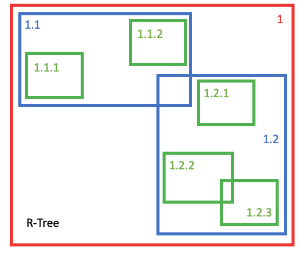

[figure not shown]

## Spatial Joins and neighbor searches

Spatial Join is the bread-and-butter of any spatial analysis.

Instead of join-keys the spatial relationships are for combining tables.

[figure not shown]

Pseudo Code Join:

```
SELECT
    id_table_1,
    id_table_2,
    attribute_table_1,
    attribute_table_2
FROM table_1
JOIN table_2
ON id_table_1 = id_table_2
```

[figure not shown]

Pseudo Code Spatial Join:

```
SELECT
    id_loc,
    id_other_loc,
    attribute_location,
    attribute_other_location
FROM locations
JOIN other_locations
ON ST_INTERSECTS(geom_loc, geom_other_loc)
```

### Example 1: Determine the postal code of a house

### Example 2: Which highways cross rivers?

### Example 3: Which buildings are inside retail areas?

# Use cases:

## Which substations are at risk of flooding?

```python
#see distance query substation - waterway in spatial_queries.sql
```

## Which fire department will put the fire out at my house?

```python
#see  fire stations and buildings query in spatial_queries.sql
```

## Spatial clustering (Tableau and Postgis)

```python
# see example spatial clustering in spatial_queries.sql
```

# E.ON Use Cases

## [Risk Monitoring for high-voltage lines](https://prodso.de/solutions/rimo/)

## [Finding the most suitable spots for Deutschland Netz charging parks](https://chargingradar.com/)

# Spatial technology stack (Python)

- Data Wrangling:
  - geopandas (pandas extension for geometric data)
  - pyproj (geographic reference systems)
  - fiona (file I/0)
  - rtree (spatial indexing)
  - pygeos (spatial indexing)
  - shapely (geometry data)
  - scipy/scikitlean (neighbor-searches)
  - networkx (network analysis)
- Plotting:
  - matplotlib (+ descartes)
  - folium (Python leaflet wrapper)
  - altair (interactive declarative visualizations)
  - datashader (plotting extremely large datasets)
- Misc:
  - osmnx, osmium (OpenStreetMap data)

# References & Acknowledgements

- https://github.com/martinchristen/bigdatabbq2021
- [PostGis Feature Overview](https://www.youtube.com/watch?v=g4DgAVCmiDE)
- [Introduction to Spatial Indexing](https://blog.crunchydata.com/blog/the-many-spatial-indexes-of-postgis)
- [PostGiS Day 2021](https://www.youtube.com/playlist?list=PLesw5jpZchudjKjwvFks-gAbz9ZZzysFm)
- [PostGiS in Action](https://www.manning.com/books/postgis-in-action-third-edition)
- [Geopandas Tutorial](https://automating-gis-processes.github.io/site/notebooks/L3/spatial_index.html)